# Tutorial 11

# Libraries

```r
library(magrittr)
library(dplyr)
library(HMM)
```

# Question 1

The dataset HSI2.csv consists of the daily closing Hang Seng Index (HSI) over the last ten years. A simple model classifies the daily indexes into three observations: up, static, down, based on the percentage changes in the indexes (changes under 0.25% are regarded as static). The goal of this analysis is to built a Hidden Markov Model (HMM) to classify the market status into one of the three states: **Bull, Even, Bear**.

```r
# Read HSI Status Data
hsi <-read.csv(file="/Users/jasonchan/MSTAT/STAT6014_Advanced_Stat_Model/Tutorial codes/Tutorial 11/HSI2.csv", header=TRUE, sep=",")

head(hsi)
```

|  | Date | Close | Change | Status |
| --- | --- | --- | --- | --- |
| 1 | 4/27/2010 | 21261.79 | -0.015067891 | D |
| 2 | 4/28/2010 | 20949.40 | -0.014692492 | D |
| 3 | 4/29/2010 | 20778.92 | -0.008137725 | D |
| 4 | 4/30/2010 | 21108.59 | 0.015865595 | U |
| 5 | 5/3/2010 | 20811.36 | -0.014081020 | D |
| 6 | 5/4/2010 | 20763.05 | -0.002321261 | S |

## Part (a)

Fit a three-state HMM to the daily observations. Draw a diagram to show the architecture of the fitted HMM, and interpret the meaning of the hidden states.

```r
# A function that generate random probability vector of length n
ranProb <- function(n) {
   p <- runif(n)
   return (p / sum(p))
}

set.seed(4272019)

# Initialize parameter estimates (3 states, 3 symbols)
initStart <- ranProb(3)
initTran <- matrix(c(ranProb(3),ranProb(3),ranProb(3)), nrow=3, byrow=TRUE)
initEmiss <- matrix(c(ranProb(3),ranProb(3),ranProb(3)), nrow=3, byrow=TRUE)

# Create a three-state HMM with randomized initital parameter estimates
hsi.hmm <- initHMM(States = c("St1","St2","St3"),
                   Symbols = c("U", "S", "D"),
                   startProbs = initStart,
                   transProbs = initTran,
                   emissionProbs = initEmiss)
hsi.hmm
```

```
$States
[1] "St1" "St2" "St3"

$Symbols
[1] "U" "S" "D"

$startProbs
       St1        St2        St3
0.06415352 0.48440996 0.45143652

$transProbs
     to
from         St1       St2       St3
  St1 0.01109107 0.3365538 0.6523552
  St2 0.18350694 0.4782782 0.3382149
  St3 0.34351938 0.3968795 0.2596011

$emissionProbs
      symbols
states         U          S          D
   St1 0.2216215 0.50253212 0.27584634
   St2 0.3731756 0.19830699 0.42851741
   St3 0.8782992 0.04427721 0.07742356
```

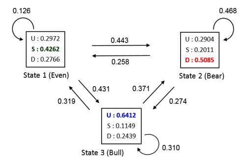

```r
# Train the HMM by Baum-Welch and print the estimated parameters
hsi.hmmfit <- baumWelch(hsi.hmm, hsi$Status, maxIteration = 100,
                        delta = 1E-9, pseudoCount = 1)
hsi.hmmfit$hmm
```

```
$States
[1] "St1" "St2" "St3"

$Symbols
[1] "U" "S" "D"

$startProbs
       St1        St2        St3
0.06415352 0.48440996 0.45143652

$transProbs
     to
from        St1       St2       St3
  St1 0.1260844 0.4431186 0.4307970
  St2 0.2577403 0.4677934 0.2744664
  St3 0.3187613 0.3713753 0.3098634

$emissionProbs
      symbols
states         U         S         D
   St1 0.2972284 0.4262171 0.2765545
   St2 0.2903780 0.2010721 0.5085499
   St3 0.6412821 0.1148634 0.2438545
```

## Part (b)

The indexes observations in the last ten days are SDSSUSDSDD. Determine the most probable state path based on the fitted HMM.

```r
# Determine most probable state path for the last ten days
# by Viterbi algorithm
lastten <- c("S","D","S","S","U","S","D","S","D","D")
path <- viterbi(hsi.hmmfit$hmm, lastten)
path
```

```
 [1] "St2" "St2" "St2" "St1" "St3" "St1" "St2" "St1" "St2" "St2"
```

# Question 2

The dataset T11Q2.csv consists of a simulated dataset with 8 binary variables. The goal of this analysis is to built a Bayesian Network (BN) to fit the data.

```r
simdata <- read.csv("/Users/jasonchan/MSTAT/STAT6014_Advanced_Stat_Model/Tutorial codes/Tutorial 11/T11Q2.csv")

head(simdata)
```

|  | A | B | D | L | R | S | T | X |
| --- | --- | --- | --- | --- | --- | --- | --- | --- |
| 1 | No | Low | Low | High | Low | Yes | Low | No |
| 2 | Yes | Low | Low | High | Low | No | Low | No |
| 3 | Yes | Low | High | High | Low | No | High | No |
| 4 | Yes | Low | Low | High | High | No | Low | Yes |
| 5 | Yes | Low | High | High | Low | No | Low | No |
| 6 | Yes | Low | High | High | Low | No | High | No |

## Part (a)

Fit a Bayesian network to the data by hill-climbing algorithm. Draw a diagram to show the fitted network structure.

```r
# Learn the DAG from data using Hill-Climbing algorithm
hcdag <- hc(simdata)

# Print the learned DAG information and plot the DAG
hcdag
```

```
  Bayesian network learned via Score-based methods

  model:
   [A][L][S|L][T|A][B|S:T][R|L:T][D|B:R][X|R]
  nodes:                                 8
  arcs:                                  9
    undirected arcs:                     0
    directed arcs:                       9
  average markov blanket size:           3.00
  average neighbourhood size:            2.25
  average branching factor:              1.12

  learning algorithm:                    Hill-Climbing
  score:                                 BIC (disc.)
  penalization coefficient:              3.912023
  tests used in the learning procedure:  119
  optimized:                             TRUE
```

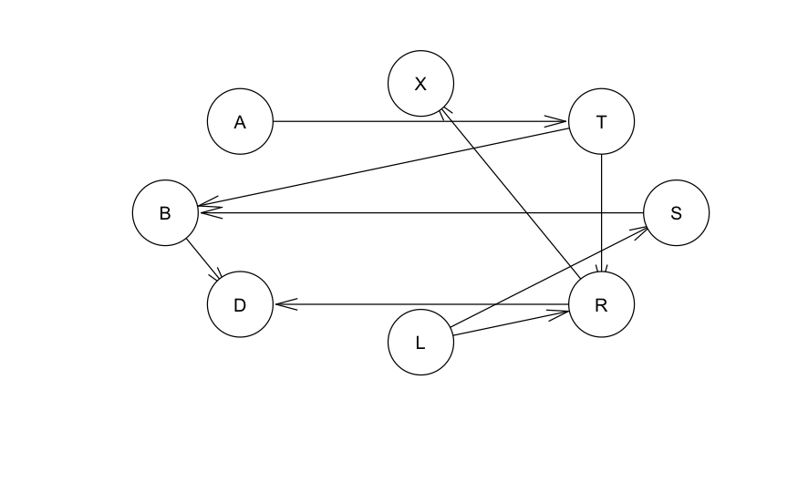

```r
plot(hcdag)
```

```r
# Parameter estimation based on the DAG learned by Hill-Climbing
hcfit <- bn.fit(hcdag, simdata, method = "mle")

# Print all the parameter estimates
hcfit
```

```
  Bayesian network parameters

  Parameters of node A (multinomial distribution)

Conditional probability table:
     No    Yes
0.2964 0.7036

  Parameters of node B (multinomial distribution)

Conditional probability table:

, , T = High

      S
B              No        Yes
  High 0.06186727 0.48511384
  Low  0.93813273 0.51488616

, , T = Low

      S
B              No        Yes
  High 0.13162119 0.54916067
  Low  0.86837881 0.45083933


  Parameters of node D (multinomial distribution)

Conditional probability table:

, , R = High

      B
D           High       Low
  High 0.8823529 0.1757720
  Low  0.1176471 0.8242280

, , R = Low

```

[output cut: 42 more lines]

```
Conditional probability table:

      A
T             No       Yes
  High 0.1133603 0.7822626
  Low  0.8866397 0.2177374

  Parameters of node X (multinomial distribution)

Conditional probability table:

     R
X           High        Low
  No  0.09813875 0.70403353
  Yes 0.90186125 0.29596647
```

## Part (b)

```r
modelstring(hcdag)
```

```
[1] "[A][L][S|L][T|A][B|S:T][R|L:T][D|B:R][X|R]"
```

Refering to the above:

$$P(A, T, L, S,B, D, R, X ) = P(A)P(L)P(S|L)P(T|A) P(B|S, T)P(R|L, T)P(D|B, R)P(X |R)$$

## Part (c)

Based on the fitted Bayesian network, determine the conditional probability of L=High given that A=Yes and R=Low

```r
# Calculate conditional probability of L="High"
# given A = "Yes" and R = "Low"
cpquery(hcfit, event = (L=="High"),
        evidence = ((A == "Yes") & (R == "Low")), method = "ls")
```

```
[1] 0.7648184
```

```r
# More accurate calculation with more samples
cpquery(hcfit, event = (L=="High"),
        evidence = ((A == "Yes") & (R == "Low")),
        method = "ls", n = 10000000)
```

```
[1] 0.758699
```